# Predicting Excessive Enforcement Patterns in Police Behavior After Vehicles Stops in New York

Model Selection and Evaluation - Logistic Regression 2-Wheels

Gianmaria Pizzo

These `.Rmd` files represent the project submission for the course [Statistical Inference and Learning](https://www.unive.it/data/course/521944) by Professor [Cristiano Varin](https://www.unive.it/data/people/5592728) at [Ca’ Foscari University of Venice](https://www.unive.it/) for the year 2025/2026.

# 0) Environment

## 0.1) Packages

```r
requirements <- c(
  "scales", "purrr", "broom", "stringr", "dplyr", "tidyr",
  "viridis", "ggplot2", "patchwork", "pROC", "kableExtra",
  "effects", "car"
)
```

Note that some of the packages may not be used, but to avoid any error related to dependencies, we are going to keep all of these libraries. Now, the loading of all packages should be immediate.

## 0.2) Functions

Here we define the helper functions used throughout model selection and evaluation, kept in one place for reuse across every model fitted below.

### 0.2.1) Data-Split Diagnostics

```r
# ==============================================================================
# 1. Train / Test Split Diagnostics
# ==============================================================================

#' @title Check Train/Test Level Proportions
#'
#' @description Tabulates one variable's level proportions separately in
#' `train` and `test` and reports the discrepancy in percentage points. Used
#' to verify that the stratified split preserved the marginal distribution of
#' key covariates.
#'
#' @param var The column name (present in both `train` and `test`) to tabulate.
#' @param label Human-readable label for the variable, stored in the output.
#'
#' @return A tibble with columns variable, level, train, test, diff_ppt.
check_prop <- function(var, label) {
  # Compute the relative frequency of each level in the training set
  tr <- prop.table(table(train[[var]]))
  # Compute the relative frequency of each level in the test set
  te <- prop.table(table(test[[var]]))
  # Create a summary table comparing train and test proportions
  tibble(
    # Variable levels
    level = names(tr),
    # Proportion in training set
    train = as.numeric(tr),
    # Proportion in test set
    test = as.numeric(te),
    # Difference in % between test and training proportions
    diff_ppt = round((as.numeric(te) - as.numeric(tr)) * 100, 2)
  ) %>%
    # Add descriptive variable name
    mutate(variable = label) %>%
    # Move variable name to first column
    relocate(variable)
}
```

### 0.2.2) Threshold and Confusion-Matrix Helpers

```r
# ==============================================================================
# 2. Threshold Selection and Confusion-Matrix Helpers
# ==============================================================================

#' @title Find the Youden-Optimal Classification Threshold
#'
#' @description Finds the probability threshold on an ROC curve that
#' maximises Youden's J statistic (sensitivity + specificity − 1), used
#' throughout as the single decision threshold for turning predicted
#' probabilities into classes.
#'
#' @param roc_obj A pROC "roc" object, as returned by pROC::roc().
#'
#' @return A numeric scalar, the optimal threshold on the probability scale.
best_thresh <- function(roc_obj) {
  pROC::coords(
    roc_obj, "best", ret = "threshold",
    best.method = "youden", quiet = TRUE
  )$threshold
}


#' @title Tally a Confusion Matrix
#'
#' @description Cross-tabulates actual vs predicted binary class labels.
#'
#' @param actual Integer/numeric vector of 0/1 true labels.
#' @param predicted Integer/numeric vector of 0/1 predicted labels.
#'
#' @return A tibble with columns Actual, Predicted, n (one row per non-empty cell).
conf_tib <- function(actual, predicted) {
  tibble(
    Actual = factor(actual, levels = c(0, 1)),
    Predicted = factor(predicted, levels = c(0, 1))
  ) %>%
    count(Actual, Predicted)
}


#' @title Plot a Confusion-Matrix Heatmap
#'
#' @description Renders conf_tib() output as a 2x2 tile plot with cell counts.
#'
#' @param actual Integer/numeric vector of 0/1 true labels.
#' @param predicted Integer/numeric vector of 0/1 predicted labels.
#' @param title Main title of the plot.
#'
#' @return A ggplot2 object.
plot_cm <- function(actual, predicted, title = "Confusion Matrix") {
  conf_tib(actual, predicted) %>%
    ggplot(aes(Predicted, Actual, fill = n)) +
    geom_tile(colour = "white") +
    geom_text(aes(label = scales::comma(n)), size = 5.5, fontface = "bold") +
    scale_fill_gradient(low = "#e8f4f8", high = "#2c7bb6", guide = "none") +
    scale_x_discrete(labels = c("0" = "No arrest", "1" = "Arrest")) +
    scale_y_discrete(labels = c("0" = "No arrest", "1" = "Arrest")) +
    labs(title = title, x = "Predicted", y = "Actual") +
    theme_minimal(base_size = 12) +
    theme(panel.grid = element_blank())
}


#' @title Compute Threshold-Dependent Classification Metrics
#'
#' @description Computes sensitivity, specificity, balanced accuracy, PPV,
#' and NPV for a fixed set of hard class predictions against the true labels.
#'
#' @param actual Integer/numeric vector of 0/1 true labels.
#' @param predicted Integer/numeric vector of 0/1 predicted labels.
#' @param pos Value in `actual`/`predicted` denoting the positive class.
#'
#' @return A named list with sensitivity, specificity, balanced_acc, ppv, npv.
class_metrics <- function(actual, predicted, pos = 1) {
  tp <- as.numeric(sum(actual == pos & predicted == pos))
  tn <- as.numeric(sum(actual != pos & predicted != pos))
  fp <- as.numeric(sum(actual != pos & predicted == pos))
  fn <- as.numeric(sum(actual == pos & predicted != pos))
  sens <- tp / (tp + fn)
  spec <- tn / (tn + fp)
  list(
    sensitivity = sens,
    specificity = spec,
    balanced_acc = (sens + spec) / 2,
    ppv = tp / (tp + fp),
    npv = tn / (tn + fn)
  )
}


# ==============================================================================
# 3. Probability-Based Evaluation Metrics
# ==============================================================================

#' @title Compute the Full Evaluation-Metrics Tibble for One Model
#'
#' @description Given predicted probabilities and true labels, computes
#' threshold-free metrics (AUC, PR-AUC, log-loss, Brier score) plus
#' threshold-dependent metrics at the Youden-optimal cut-off (sensitivity,
#' specificity, precision, F1, MCC, balanced accuracy). Returns one row per
#' call, so results from multiple models can be row-bound into a comparison
#' table.
#'
#' @param actual Integer/numeric vector of 0/1 true labels.
#' @param prob Numeric vector of predicted P(arrested = 1), same length as `actual`.
#' @param thr Classification threshold selected externally (on the training set),
#' applied here rather than recomputed from `actual`/`prob` to avoid leaking test labels.
#' @param model_name Label stored in the Model column.
#'
#' @return A one-row tibble of rounded metrics (see column names in the body).
compute_metrics <- function(actual, prob, thr, model_name = "Model") {
  valid <- !is.na(actual) & !is.na(prob)
  actual <- actual[valid]
  prob <- prob[valid]

  roc_obj <- pROC::roc(actual, prob, quiet = TRUE)
  auc_val <- as.numeric(pROC::auc(roc_obj))
  pred_cl <- as.integer(prob >= thr)

  # Confusion Matrix Metrics
  tp <- as.numeric(sum(actual == 1 & pred_cl == 1))
  tn <- as.numeric(sum(actual == 0 & pred_cl == 0))
  fp <- as.numeric(sum(actual == 0 & pred_cl == 1))
  fn <- as.numeric(sum(actual == 1 & pred_cl == 0))

  # Confusion Matrix Derived Metrics
  sens <- (
    if ((tp+fn) == 0) NA_real_
    else tp / (tp+fn)
  )
  spec <- (
    if ((tn+fp) == 0) NA_real_
    else tn / (tn+fp)
  )
  prec <- (
    if ((tp+fp) == 0) NA_real_
    else tp / (tp+fp)
  )
  f1 <- (
    if (is.na(prec) || is.na(sens) || (prec+sens) == 0) NA_real_
    else 2 * prec * sens / (prec + sens)
  )

  # MCC
  mcc_den <- sqrt(
    as.numeric(tp+fp) * as.numeric(tp+fn) *
    as.numeric(tn+fp) * as.numeric(tn+fn)
  )
  mcc_val <- (
    if (mcc_den == 0) NA_real_
    else (tp*tn - fp*fn) / mcc_den
  )

  # Logloss
  eps <- 1e-15
  logloss <- -mean(
    actual * log(pmax(prob, eps)) +
    (1-actual) * log(pmax(1-prob, eps))
  )

  # Brier Score
  brier <- mean((prob - actual)^2)

  # PR-AUC via trapezoid rule over pROC coords (pROC has no built-in PR-AUC)
  pr_raw <- pROC::coords(
    roc_obj, "all", ret = c("sensitivity", "precision"),
    transpose = FALSE, drop = FALSE
  )

  names(pr_raw)[names(pr_raw) == "sensitivity"] <- "recall"

  pr_raw <- pr_raw %>%
    filter(!is.nan(precision), !is.na(precision), !is.nan(recall)) %>%
    arrange(recall)

  pr_auc_val <- if (nrow(pr_raw) >= 2)
    sum(diff(pr_raw$recall) * (head(pr_raw$precision, -1) + tail(pr_raw$precision, -1)) / 2)
  else NA_real_

  # Print Metrics
  tibble(
    Model = model_name,
    AUC = round(auc_val, 4),
    PR_AUC = round(pr_auc_val, 4),
    Log_Loss = round(logloss, 4),
    Brier = round(brier, 4),
    Threshold = round(thr, 4),
    Sensitivity = round(sens, 3),
    Specificity = round(spec, 3),
    Precision = round(prec, 3),
    F1 = round(f1, 3),
    MCC = round(mcc_val, 3),
    Bal_Acc = round(
      if (!is.na(sens) && !is.na(spec)) (sens+spec)/2
      else NA_real_, 3
    )
  )
}
```

### 0.2.3) Model Evaluation Plot Functions

```r
# ==============================================================================
# 4. Plots for Single-Model Evaluation
# ==============================================================================

#' @title Plot the ROC Curve for a Single Model
#'
#' @description Plots sensitivity vs specificity across all thresholds, with
#' the AUC annotated on the panel.
#'
#' @param actual Integer/numeric vector of 0/1 true labels.
#' @param prob Numeric vector of predicted P(arrested = 1), same length as `actual`.
#' @param title Main title of the plot.
#'
#' @return A ggplot2 object.
plot_roc_single <- function(actual, prob, title = "ROC Curve") {
  roc_obj <- pROC::roc(actual, prob, quiet = TRUE)
  auc_lbl <- paste0("AUC = ", round(as.numeric(pROC::auc(roc_obj)), 4))
  pROC::ggroc(roc_obj, colour = "#2c7bb6", linewidth = 0.9) +
    geom_abline(slope = 1, intercept = 1, linetype = "dashed", colour = "grey60") +
    annotate("text", x = 0.25, y = 0.06, label = auc_lbl, colour = "#2c7bb6", size = 4) +
    labs(x = "Specificity", y = "Sensitivity", title = title) +
    theme_minimal(base_size = 11) + theme(panel.grid.minor = element_blank())
}
```

```r
#' @title Plot the Precision-Recall Curve for a Single Model
#'
#' @description Plots precision vs recall across all thresholds against the
#' no-skill baseline (the class prevalence), with PR-AUC annotated. More
#' informative than the ROC curve under the severe class imbalance here.
#'
#' @param actual Integer/numeric vector of 0/1 true labels.
#' @param prob Numeric vector of predicted P(arrested = 1), same length as `actual`.
#' @param title Main title of the plot.
#'
#' @return A ggplot2 object.
plot_pr_single <- function(actual, prob, title = "Precision-Recall Curve") {
  roc_obj <- pROC::roc(actual, prob, quiet = TRUE)
  pr_raw  <- pROC::coords(
    roc_obj, "all", ret = c("sensitivity", "precision"),
    transpose = FALSE, drop = FALSE
  )
  names(pr_raw)[names(pr_raw) == "sensitivity"] <- "recall"
  pr_df <- pr_raw %>%
    filter(!is.nan(precision), !is.na(precision)) %>%
    arrange(recall)

  # PR-AUC via trapezoid rule, same approach as in compute_metrics()
  pr_auc_lbl <- if (nrow(pr_df) >= 2) {
    v <- sum(diff(pr_df$recall) *
               (head(pr_df$precision,-1) + tail(pr_df$precision,-1)) / 2)
    paste0("PR-AUC = ", round(v, 4))
  } else "PR-AUC = NA"
  baseline <- mean(actual)
  ggplot(pr_df, aes(x = recall, y = precision)) +
    geom_line(colour = "#d73027", linewidth = 0.9) +
    geom_hline(yintercept = baseline, linetype = "dashed", colour = "grey55") +
    annotate("text", x = 0.02, y = baseline + 0.015,
             label = paste0("No-skill = ", round(baseline, 3)),
             colour = "grey40", size = 3.2, hjust = 0) +
    annotate("text", x = 0.55, y = 0.90, label = pr_auc_lbl,
             colour = "#d73027", size = 4) +
    scale_x_continuous(limits = c(0, 1)) + scale_y_continuous(limits = c(0, 1)) +
    labs(x = "Recall", y = "Precision", title = title) +
    theme_minimal(base_size = 11) + theme(panel.grid.minor = element_blank())
}
```

```r
#' @title Plot the Calibration (Reliability) Curve for a Single Model
#'
#' @description Bins predictions into `n_bins` equal-frequency groups and
#' plots mean predicted probability against observed positive rate per bin,
#' against the perfect-calibration diagonal.
#'
#' @param actual Integer/numeric vector of 0/1 true labels.
#' @param prob Numeric vector of predicted P(arrested = 1), same length as `actual`.
#' @param title Main title of the plot.
#' @param n_bins Number of quantile bins of `prob`.
#'
#' @return A ggplot2 object.
plot_calibration_single <- function(actual, prob, title = "Calibration Plot",
                                    n_bins = 10) {
  # Quantile breaks (not equal-width) so each bin has a comparable sample size
  # despite the predicted probabilities being heavily right-skewed
  brks  <- unique(quantile(prob, seq(0, 1, length.out = n_bins + 1), na.rm = TRUE))
  cal_df <- tibble(actual = actual, prob = prob) %>%
    mutate(bin = cut(prob, breaks = brks, include.lowest = TRUE)) %>%
    filter(!is.na(bin)) %>%
    group_by(bin) %>%
    summarise(mean_pred = mean(prob), mean_obs = mean(actual),
              n = n(), .groups = "drop")
  ggplot(cal_df, aes(x = mean_pred, y = mean_obs)) +
    geom_abline(slope = 1, intercept = 0, linetype = "dashed", colour = "grey55") +
    geom_line(colour = "#2c7bb6", linewidth = 0.8) +
    geom_point(aes(size = n), colour = "#2c7bb6", alpha = 0.85) +
    scale_size_continuous(name = "Count", range = c(2, 9)) +
    scale_x_continuous(labels = scales::percent_format(accuracy = 0.1)) +
    scale_y_continuous(labels = scales::percent_format(accuracy = 0.1)) +
    labs(x = "Mean predicted probability", y = "Observed positive rate",
         title = title,
         caption = "Size ∝ bin count.  Dashed = perfect calibration.") +
    theme_minimal(base_size = 11) +
    theme(legend.position = "bottom", panel.grid.minor = element_blank())
}
```

```r
#' @title Plot the Threshold-Sweep Metrics for a Single Model
#'
#' @description Plots sensitivity, specificity, precision, and F1 as
#' functions of the classification threshold, with the Youden-optimal
#' threshold marked.
#'
#' @param actual Integer/numeric vector of 0/1 true labels.
#' @param prob Numeric vector of predicted P(arrested = 1), same length as `actual`.
#' @param thr Classification threshold selected externally (on the training set).
#' @param title Main title of the plot.
#'
#' @return A ggplot2 object.
plot_threshold_single <- function(actual, prob, thr, title = "Threshold Analysis") {
  roc_obj  <- pROC::roc(actual, prob, quiet = TRUE)
  thr_data <- pROC::coords(roc_obj, "all",
                            ret = c("threshold","sensitivity","specificity","precision"),
                            transpose = FALSE, drop = FALSE) %>%
    filter(is.finite(threshold), threshold >= 0, threshold <= 1) %>%
    mutate(f1 = ifelse(!is.nan(precision) & (precision + sensitivity) > 0,
                       2 * precision * sensitivity / (precision + sensitivity), 0)) %>%
    pivot_longer(c(sensitivity, specificity, precision, f1),
                 names_to = "Metric", values_to = "Value") %>%
    mutate(Metric = dplyr::recode(Metric,
      sensitivity = "Sensitivity", specificity = "Specificity",
      precision   = "Precision",   f1          = "F1 Score"))
  ggplot(thr_data, aes(x = threshold, y = Value, colour = Metric)) +
    geom_line(linewidth = 0.75, na.rm = TRUE) +
    geom_vline(xintercept = thr, linetype = "dashed",
               colour = "grey35", linewidth = 0.55) +
    annotate("text", x = thr, y = 0.04,
             label = paste0("Train-selected\n", round(thr, 3)),
             hjust = -0.08, size = 3, colour = "grey30") +
    scale_colour_viridis_d(option = "turbo", begin = 0.05, end = 0.92) +
    scale_y_continuous(limits = c(0, 1)) +
    labs(x = "Threshold", y = "Metric value", colour = NULL, title = title,
         caption = "Dashed: threshold selected on the training set") +
    theme_minimal(base_size = 11) +
    theme(legend.position = "bottom", panel.grid.minor = element_blank())
}
```

```r
#' @title Plot the 2x2 Evaluation Panel for a Single Model
#'
#' @description Composes plot_roc_single(), plot_pr_single(),
#' plot_calibration_single(), and plot_threshold_single() into one
#' (ROC | PR) / (Calibration | Threshold) patchwork layout.
#'
#' @param actual Integer/numeric vector of 0/1 true labels.
#' @param prob Numeric vector of predicted P(arrested = 1), same length as `actual`.
#' @param thr Classification threshold selected externally (on the training set).
#' @param model_name Prefixed to each sub-plot's title.
#'
#' @return A patchwork object (composed ggplot2 object).
eval_quad_plot <- function(actual, prob, thr, model_name) {
  p1 <- plot_roc_single(actual, prob,   paste(model_name, "— ROC"))
  p2 <- plot_pr_single(actual, prob,    paste(model_name, "— Precision-Recall"))
  p3 <- plot_calibration_single(actual, prob, paste(model_name, "— Calibration"))
  p4 <- plot_threshold_single(actual, prob, thr, paste(model_name, "— Threshold Analysis"))
  (p1 | p2) / (p3 | p4)
}
```

# 1) Data Loading and Preparation

```r
vehstop <- read.csv("data/vehiclestops_2_wheels_final.csv")
```

## 1.1) Factor conversion and Reference Levels

We convert all categorical predictors to factors and set interpretable reference levels before any modelling step, ensuring consistency between all downstream model fits and cross-validation folds.

```r
# Ordered weekday levels (ISO order)
wday_levels <- c("Monday", "Tuesday", "Wednesday", "Thursday", "Friday", "Saturday", "Sunday")

# Ordered time bracket levels
tbkt_levels <- c(
  "Late night (0–3)",
  "Early morning (4–7)",
  "Morning commute (8–11)",
  "Midday (12–15)",
  "Afternoon/evening (16–19)",
  "Night (20–23)"
)

# Ordered age-bracket levels
abkt_levels <- c("Under 18", "18–24", "25–34", "35–44", "45–54", "55–64", "65+", "Unknown")

vehstop <- vehstop %>%
  mutate(
    year = factor(year),
    month = factor(month, levels = 1:12),
    weekday = factor(weekday, levels = wday_levels),
    hour = factor(hour, levels = 0:23),
    time_bracket = factor(time_bracket, levels = tbkt_levels),
    area = factor(area),
    boro = factor(boro),
    sex = factor(sex),
    ethnicity = factor(ethnicity),
    age_bracket = factor(age_bracket, levels = abkt_levels)
  )

# Reference levels chosen for interpretable contrasts
vehstop$sex <- relevel(vehstop$sex, ref = "M")
vehstop$ethnicity <- relevel(vehstop$ethnicity, ref = "White")
vehstop$weekday <- relevel(vehstop$weekday, ref = "Monday")
vehstop$time_bracket <- relevel(vehstop$time_bracket, ref = "Morning commute (8–11)")
vehstop$age_bracket <- relevel(vehstop$age_bracket, ref = "25–34")

rm(wday_levels, tbkt_levels, abkt_levels)
```

## 1.2) Stratified Train / Test Split

For the train/test split, a **stratified sampling approach** is used to ensure that the training and test sets have comparable distributions of the outcome variable (`arrested`) and relevant contextual variables.

This is particularly important because the target variable is imbalanced, with arrested cases representing only a small proportion of all observations. Rather than stratifying only on `arrested`, the code constructs a **joint stratification variable** from `arrested`, `area`, `sex`, `ethnicity`, and `hour` using `interaction()`. Thus, each observation is assigned to a stratum corresponding to a particular combination of these variables.

Formally, the strata can be represented as

$$S_i =
(\text{arrested}_i,\text{area}_i,\text{sex}_i,\text{ethnicity}_i,\text{hour}_i),$$

where $S_i$ denotes the stratum to which observation $i$ belongs. The objective is to sample approximately 80% of observations within each stratum for the training set and retain the remaining 20% for testing:

$$P(i \in \mathcal{D}_{train} \mid S_i=s)
\approx 0.8,
\qquad
P(i \in \mathcal{D}_{test} \mid S_i=s) \approx 0.2.$$

```r
set.seed(2026)

# Joint stratum key; drop = TRUE removes empty combinations
vehstop$.strat <- interaction(
  vehstop$arrested, vehstop$area, vehstop$sex, vehstop$ethnicity, vehstop$hour,
  drop = TRUE
)

train_rows <- vehstop %>%
  dplyr::mutate(.row = row_number()) %>%
  dplyr::group_by(.strat) %>%
  dplyr::slice_sample(prop = 0.8) %>%
  dplyr::pull(.row)

train <- vehstop[ train_rows, ] %>% dplyr::select(-.strat)
test <- vehstop[-train_rows, ] %>% dplyr::select(-.strat)
vehstop <- vehstop %>% dplyr::select(-.strat)
```

In the code, `group_by(.strat) %>% slice_sample(prop = 0.8)` performs this within-stratum sampling, while the observations not selected for training form the test set. This approach aims to preserve not only the overall prevalence of the outcome,

$$P_{\text{train}}(\text{arrested}=1)
\approx P_{\text{test}}(\text{arrested}=1),$$

but also the composition of the data across geographic, demographic, and temporal characteristics. This is desirable because differences in these characteristics could otherwise introduce an unintended distributional difference between the training and test sets. The temporary `.strat` variable is removed after the split because it is used solely to define the sampling groups and is not intended to be used as a predictor in the subsequent modelling.

Finally, the verification code compares the empirical marginal distributions of `arrested`, `area`, `sex`, and `ethnicity` in the two datasets. For a variable $X$ and level $k$, the proportion in each dataset is calculated as

$$\hat{P}_{train}(X=k)
=
\frac{\sum_{i \in \mathcal{D}_{train}} \mathbb{I}(X_i=k)}
{|\mathcal{D}_{train}|},$$

and analogously for the test set. The difference is then reported in **percentage points**:

$$\Delta_k =
100\left[
\hat{P}_{test}(X=k)
-
\hat{P}_{train}(X=k)
\right].$$

Small values of $\Delta_k$ indicate that the corresponding characteristic is similarly represented in the two datasets. The final summary additionally compares the number of observations and the proportion of arrested cases in the training and test sets, providing a direct check that the intended approximately 80/20 split and the class distribution have been maintained.

```r
bind_rows(
  check_prop("arrested", "arrested"),
  check_prop("area", "area"),
  check_prop("sex", "sex"),
  check_prop("ethnicity", "ethnicity")
) %>%
  kbl(
    digits = 4,
    caption = "Proportion of each level in train vs test (diff in percentage points)",
    col.names = c("Variable", "Level", "Train", "Test", "Δ (ppt)")
  ) %>%
  kable_styling(bootstrap_options = c("striped", "hover", "condensed"), full_width = FALSE) %>%
  collapse_rows(columns = 1, valign = "top")
```

Proportion of each level in train vs test (diff in percentage points)

| Variable | Level | Train | Test | Δ (ppt) |
| --- | --- | --- | --- | --- |
| arrested | 0 | 0.9462 | 0.9370 | -0.92 |
|  | 1 | 0.0538 | 0.0630 | 0.92 |
| area | Bronx | 0.1574 | 0.1585 | 0.12 |
|  | Brooklyn | 0.2961 | 0.2939 | -0.22 |
|  | Manhattan | 0.2689 | 0.2678 | -0.11 |
|  | Queens | 0.2705 | 0.2690 | -0.15 |
|  | Staten Island | 0.0070 | 0.0107 | 0.37 |
| sex | M | 0.9602 | 0.9475 | -1.27 |
|  | F | 0.0352 | 0.0444 | 0.92 |
|  | U | 0.0046 | 0.0081 | 0.35 |
| ethnicity | White | 0.0971 | 0.0995 | 0.24 |
|  | Asian / Pacific Islander | 0.1096 | 0.1104 | 0.07 |
|  | Black | 0.2066 | 0.2060 | -0.06 |
|  | Hispanic | 0.4778 | 0.4699 | -0.78 |
|  | Other | 0.0162 | 0.0188 | 0.26 |
|  | Unknown | 0.0928 | 0.0955 | 0.26 |

```r
cat(sprintf(
  "Training set : %d rows  |  Arrested: %.2f%%\nTest set     : %d rows  |  Arrested: %.2f%%\n",
  nrow(train), 100 * mean(train$arrested),
  nrow(test),  100 * mean(test$arrested)
))
```

```
## Training set : 150691 rows  |  Arrested: 5.38%
## Test set     : 38851 rows  |  Arrested: 6.30%
```

```r
# Remove vehstop for memory purposes
rm(vehstop)
```

# 3) Full Logistic Regression

Here, logistic regression models the conditional probability of belonging to the positive class through the logit transformation,

$$\log\left( \frac{p(X)}{1-p(X)} \right) =
\beta_0 + \beta_1 X_1 + \cdots + \beta_p X_{p}$$

where $p(X)=P(Y=1\mid X)$.

We considered this model for the following reasons

1. First of all, our response `arrested` is **binary** and this makes the binomial logistic model a natural choice for estimating the probability of an arrest.
2. Then we want to exploit its **interpretability**: each coefficient describes the association between a predictor and the log-odds of arrest while holding the other variables fixed. This allows the model to be used not only as a classifier, but also to **investigate** how demographic, time-related and geographic features **are associated with the probability of arrest**.
3. Finally, logistic regression provides a useful **baseline model**. This makes it possible to assess if other models (LASSO, GAM, or Naive Bayes) can be better with respect to predictive power and to analyze the differences in additional complexity.

## 3.1) Assumptions and Setup

We had to exclude `age` as a predictor, since we had missing values that we labeled as `Unknown` in `age_bracket`. Therefore, this is the final formulation of the model

```r
f_final <- arrested ~ year + month + weekday + hour + boro + sex + ethnicity + age_bracket
```

## 3.2) Final Model Fit

```r
mod_logit_best <- glm(f_final, family = binomial, data = train)
```

## 3.3) Specific Analysis and Interpretation

```r
summary(mod_logit_best)
```

```
##
## Call:
## glm(formula = f_final, family = binomial, data = train)
##
## Coefficients:
##                                   Estimate Std. Error z value Pr(>|z|)
## (Intercept)                       -2.32968    0.10204 -22.832  < 2e-16 ***
## year2024                           0.15106    0.03696   4.087 4.37e-05 ***
## year2025                           0.19055    0.03612   5.275 1.32e-07 ***
## month2                             0.04513    0.07243   0.623 0.533196
## month3                             0.02145    0.06926   0.310 0.756772
## month4                             0.12973    0.06525   1.988 0.046793 *
## month5                             0.15312    0.06381   2.400 0.016409 *
## month6                             0.17949    0.06222   2.885 0.003918 **
## month7                             0.22279    0.06131   3.634 0.000279 ***
## month8                             0.07152    0.06262   1.142 0.253386
## month9                             0.21123    0.06192   3.411 0.000646 ***
## month10                            0.16622    0.06178   2.691 0.007132 **
## month11                            0.11228    0.06466   1.737 0.082470 .
## month12                           -0.10374    0.07315  -1.418 0.156158
## weekdayTuesday                     0.14199    0.04816   2.949 0.003193 **
## weekdayWednesday                   0.04666    0.04736   0.985 0.324601
## weekdayThursday                    0.02371    0.04760   0.498 0.618334
## weekdayFriday                     -0.13612    0.04922  -2.766 0.005679 **
## weekdaySaturday                   -0.07786    0.04965  -1.568 0.116830
## weekdaySunday                     -0.12706    0.05092  -2.495 0.012593 *
## hour1                             -0.03899    0.08185  -0.476 0.633841
## hour2                              0.16069    0.09592   1.675 0.093887 .
## hour3                              0.12973    0.11879   1.092 0.274806
## hour4                             -0.49369    0.19003  -2.598 0.009379 **
## hour5                             -1.24473    0.25147  -4.950 7.43e-07 ***
## hour6                             -2.48578    0.33861  -7.341 2.12e-13 ***
## hour7                             -3.35466    0.38202  -8.781  < 2e-16 ***
## hour8                             -2.09283    0.15378 -13.609  < 2e-16 ***
## hour9                             -1.86890    0.12466 -14.992  < 2e-16 ***
## hour10                            -1.87590    0.12076 -15.535  < 2e-16 ***
## hour11                            -1.42235    0.09721 -14.631  < 2e-16 ***
## hour12                            -1.14051    0.08635 -13.208  < 2e-16 ***
## hour13                            -0.76616    0.07672  -9.987  < 2e-16 ***
## hour14                            -0.50636    0.07234  -7.000 2.56e-12 ***
```

[output cut: 25 more lines]

```
## age_bracket35–44                   0.09586    0.03315   2.891 0.003834 **
## age_bracket45–54                   0.19085    0.04504   4.238 2.26e-05 ***
## age_bracket55–64                   0.32738    0.06083   5.382 7.39e-08 ***
## age_bracket65+                    -0.10389    0.17384  -0.598 0.550084
## age_bracketUnknown                 0.21929    0.05219   4.201 2.65e-05 ***
## ---
## Signif. codes:  0 '***' 0.001 '**' 0.01 '*' 0.05 '.' 0.1 ' ' 1
##
## (Dispersion parameter for binomial family taken to be 1)
##
##     Null deviance: 63178  on 150690  degrees of freedom
## Residual deviance: 57191  on 150627  degrees of freedom
## AIC: 57319
##
## Number of Fisher Scoring iterations: 8
```

The model improves the fit compared with the intercept-only model. The **null deviance** decreases from $63,178$ to a **residual deviance** of $57,191$, corresponding to a reduction of $5,987$ deviance units with $63$ additional parameters.

Even though this suggests that our predictors contribute to explaining the probability of arrest, the residual deviance remains relatively large. Unfortunately, this means that a considerable amount of variation is still not captured by the model.

This is what we expected given that the model is simple and has an additive form (we do not consider interactions or non-linear effects here for interpretability).

### 3.3.1) Coefficients analysis

The coefficients are estimated by maximum likelihood and describe changes in the log-odds of the positive outcome/arrests (`arrested = 1`) while holding the remaining predictors fixed.

When several predictors are **categorical**, each factor with $K$ levels is represented through $K-1$ indicator variables relative to a chosen reference category. In this case, the estimated coefficients represent changes in the **log-odds of arrest**, relative to the corresponding reference category and conditional on all other predictors being held fixed.

The intercept ($-2.330$) represents the estimated **log-odds of arrest for the reference level**. In other words, an observation belonging to all reference categories of the categorical predictors (see section 1.1). Its negative value suggests that we have a relatively low baseline probability of arrest (approximately $8.9\%$), which is also significant ($p<2 \times 10^{-16}$).

Overall, the coefficient estimates suggest that `hour`, `boro`, `sex`, `ethnicity`, and `age_bracket` **contain the strongest conditional signals in the fitted model**, while `month` and `weekday` show smaller contributions.

Let us see the predictors now.

#### 3.3.1.1) Time-related

First of all, we consider the time-related predictors:

- `year`: The coefficients for **2024** ($0.151$) and **2025** ($0.191$) are both positive and statistically significant, indicating **higher conditional log-odds of arrest than in 2023** (reference year);
- `month`: In general, monthly effects are comparatively modest. Relative to January, April through July generally show positive coefficients, with the largest occurring in **July** ($0.223$). September ($0.211$) and October ($0.166$) also show significant positive differences. In contrast, several months, including February, March, August and December, do not differ significantly from January.
- `weekday` differences are also relatively small. **Tuesday** has a positive coefficient ($0.142$), while **Friday** ($-0.136$) and **Sunday** ($-0.127$) are significantly lower than Monday.
- `hour`: The strongest temporal pattern is associated with **hour of the day**. Relative to midnight, coefficients become strongly negative during the morning, reaching their minimum at **07:00** ($-3.355$). Large negative coefficients are also observed between approximately 06:00 and 12:00. The magnitude then progressively decreases during the afternoon and evening, with coefficients approaching zero again by 23:00. This indicates a pronounced time-of-day structure that cannot be summarized as a simple linear trend.

#### 3.3.1.2) Borough

Then we look at `boro` for the geographic coefficients.

- **All its coefficients are significant and negative relative to the reference borough (Bronx)**.
- The largest differences are observed for **Manhattan North** ($-1.103$), **Manhattan South** ($-1.067$), and **Queens North** ($-0.939$). Brooklyn North also shows a substantial negative coefficient ($-0.878$).
- This heterogeneity in arrest patterns suggests that our decision to use `boro` instead of `area` was somewhat worth it.

#### 3.3.1.3) Sex

For what concerns `sex`

- The coefficient for **Female** is strongly negative ($-1.204$) and highly significant relative to `sexM`.
- In contrast, the coefficient for **Unknown sex** ($-0.053$) is close to zero and not statistically significant, providing little evidence of a difference from the reference category after adjustment for the other predictors.

#### 3.3.1.4) Ethnicity

The `ethnicity` coefficients show marked differences relative to the reference category.

- **Black** ($0.372$) and **Hispanic** ($0.575$) have positive and statistically significant coefficients, while **Asian / Pacific Islander** ($-0.711$), **Other** ($-2.288$), and **Unknown** ($-1.109$) have negative coefficients.
- Among these, `ethnicityOther` has the largest absolute coefficient. However, its relatively large standard error ($0.338$) suggests greater uncertainty than for the more frequent categories.

#### 3.3.1.5) Age Bracket

Finally for `age_bracket`, using age 25–34 as the reference category,

- The strongest positive coefficient is observed for individuals **under 18** ($0.545$).
- Positive coefficients are also found for ages 35–44 ($0.096$), 45–54 ($0.191$), and 55–64 ($0.327$).
- The coefficient for age 18–24 is small ($0.072$), although statistically significant $p = 0.021894$, while the coefficient for **65+** ($-0.104$) is not significant $p = 0.550084$.
- The `Unknown` age category has a positive coefficient of $0.219$.

### 3.3.2) Odd Ratios, Significance and Effects

In logistic regression, coefficients are estimated on the **log-odds scale**, which can be difficult to interpret directly. Thus, they are often transformed into **odds ratios**

$$OR=e^{\beta}$$

For a categorical predictor, the odds ratio **compares the odds of arrest for a given category with those of its reference category, while holding all other predictors fixed**. We say that

- $OR>1$ indicates higher odds of arrest, relative to the reference group (while holding all other predictors fixed);
- $OR<1$ indicates lower odds, relative to the reference group (while holding all other predictors fixed);
- $OR=1$ indicates no difference, relative to the reference group (while holding all other predictors fixed).

```r
predictors <- c("year", "month", "weekday", "hour", "boro", "sex", "ethnicity", "age_bracket")

or_tbl <- tidy(mod_logit_best, conf.int = FALSE, exponentiate = FALSE) %>%
  filter(term != "(Intercept)") %>%
  mutate(
    conf.low = exp(estimate - qnorm(0.975) * std.error),
    conf.high = exp(estimate + qnorm(0.975) * std.error),
    estimate = exp(estimate),
    group = purrr::map_chr(term, function(t) {
      g <- predictors[purrr::map_lgl(predictors, ~ startsWith(t, .x))]
      if (length(g) == 0) "Other" else g[which.max(nchar(g))]
    }),
    level = purrr::map2_chr(term, group, ~ sub(paste0("^", .y), "", .x)),
    sig = case_when(
      p.value < 0.001 ~ "***",
      p.value < 0.01 ~ "**",
      p.value < 0.05 ~ "*",
      p.value < 0.1 ~ ".",
      TRUE ~ ""
    )
  ) %>%
  select(group, level, estimate, conf.low, conf.high, p.value, sig)

or_tbl %>%
  kbl(
    digits = 3,
    caption = "Odds ratios with 95% CI and significance (reference levels: year=2023, month=Jan, weekday=Mon, hour=0, boro=Bronx, sex=M, ethnicity=White, age_bracket=25-34)",
    col.names = c("Group", "Level vs Reference", "OR", "CI 2.5%", "CI 97.5%", "p-value", "")
  ) %>%
  kable_styling(bootstrap_options = c("striped", "hover", "condensed"), full_width = FALSE) %>%
  collapse_rows(columns = 1, valign = "top")
```

Odds ratios with 95% CI and significance (reference levels: year=2023, month=Jan, weekday=Mon, hour=0, boro=Bronx, sex=M, ethnicity=White, age_bracket=25-34)

Group

Level vs Reference

OR

CI 2.5%

CI 97.5%

p-value

year

2024

1.163

1.082

1.250

0.000

***

2025

1.210

1.127

1.299

0.000

***

month

2

1.046

0.908

1.206

0.533

3

1.022

0.892

1.170

0.757

4

1.139

1.002

1.294

0.047

5

1.165

1.028

1.321

0.016

6

1.197

1.059

1.352

0.004

7

1.250

1.108

1.409

0.000

***

8

1.074

0.950

1.214

0.253

9

1.235

1.094

1.395

0.001

***

10

1.181

1.046

1.333

0.007

11

1.119

0.986

1.270

0.082

.

12

0.901

0.781

1.040

0.156

weekday

Tuesday

1.153

1.049

1.267

0.003

Wednesday

1.048

0.955

1.150

0.325

Thursday

1.024

0.933

1.124

0.618

Friday

0.873

0.792

0.961

0.006

Saturday

0.925

0.839

1.020

0.117

Sunday

0.881

0.797

0.973

0.013

hour

1

0.962

0.819

1.129

0.634

2

1.174

0.973

1.417

0.094

.

3

1.139

0.902

1.437

0.275

4

0.610

0.421

0.886

0.009

5

0.288

0.176

0.471

0.000

***

6

0.083

0.043

0.162

0.000

***

7

0.035

0.017

0.074

0.000

***

8

0.123

0.091

0.167

0.000

***

9

0.154

0.121

0.197

0.000

***

10

0.153

0.121

0.194

0.000

***

11

0.241

0.199

0.292

0.000

***

12

0.320

0.270

0.379

0.000

***

13

0.465

0.400

0.540

0.000

***

14

0.603

0.523

0.694

0.000

***

15

0.567

0.492

0.654

0.000

***

16

0.560

0.491

0.640

0.000

***

17

0.588

0.517

0.670

0.000

***

18

0.735

0.652

0.830

0.000

***

19

0.790

0.703

0.888

0.000

***

20

0.792

0.703

0.892

0.000

***

21

0.844

0.746

0.953

0.006

22

0.880

0.774

1.002

0.053

.

23

0.972

0.849

1.114

0.683

boro

Brooklyn (North)

0.416

0.385

0.448

0.000

***

Brooklyn (South)

0.614

0.571

0.660

0.000

***

Manhattan (North)

0.332

0.305

0.361

0.000

***

Manhattan (South)

0.344

0.311

0.381

0.000

***

Queens (North)

0.391

0.363

0.421

0.000

***

Queens (South)

0.502

0.457

0.552

0.000

***

Staten Island

0.631

0.487

0.819

0.001

***

sex

F

0.300

0.237

0.380

0.000

***

U

0.948

0.498

1.804

0.871

ethnicity

Asian / Pacific Islander

0.491

0.422

0.572

0.000

***

Black

1.451

1.298

1.622

0.000

***

Hispanic

1.778

1.598

1.977

0.000

***

Other

0.102

0.052

0.197

0.000

***

Unknown

0.330

0.274

0.397

0.000

***

age_bracket

Under 18

1.725

1.524

1.953

0.000

***

18–24

1.075

1.010

1.143

0.022

35–44

1.101

1.031

1.175

0.004

45–54

1.210

1.108

1.322

0.000

***

55–64

1.387

1.231

1.563

0.000

***

65+

0.901

0.641

1.267

0.550

Unknown

1.245

1.124

1.379

0.000

***

Since this is not easy to visualize, we use the below to display estimated odds ratios with 95% confidence intervals, faceted by predictor

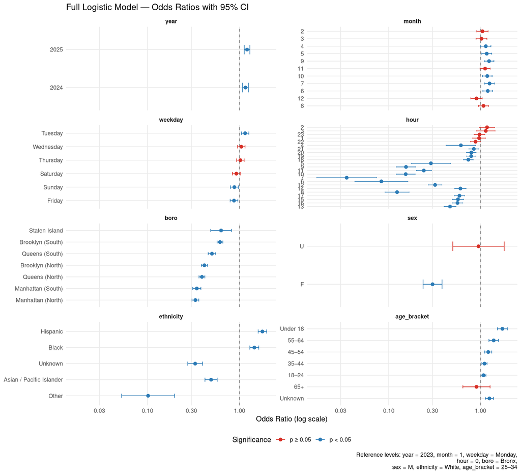

```r
or_plot_data <- or_tbl %>%
  mutate(
    is_sig = p.value < 0.05,
    level = stringr::str_wrap(level, width = 28),
    group = factor(
      group,
      levels = c(
        "year", "month", "weekday", "hour",
        "boro", "sex", "ethnicity", "age_bracket"
      )
    )
  )

ggplot(
  or_plot_data,
  aes(x = estimate, y = reorder(level, estimate), colour = is_sig)
) +
  geom_vline(xintercept = 1, linetype = "dashed", colour = "grey55", linewidth = 0.5) +
  geom_errorbarh(aes(xmin = conf.low, xmax = conf.high), height = 0.25, linewidth = 0.45) +
  geom_point(size = 2) +
  scale_x_log10(labels = scales::number_format(accuracy = 0.01)) +
  scale_colour_manual(
    values = c("TRUE" = "#2c7bb6", "FALSE" = "#d73027"),
    labels = c("TRUE" = "p < 0.05", "FALSE" = "p ≥ 0.05")
  ) +
  facet_wrap(~ group, scales = "free_y", ncol = 2) +
  labs(
    x = "Odds Ratio (log scale)",
    y = NULL,
    colour = "Significance",
    title = "Full Logistic Model — Odds Ratios with 95% CI",
    caption = paste0(
      "Reference levels: year = 2023, month = 1, weekday = Monday,\n",
      "hour = 0, boro = Bronx,\n",
      "sex = M, ethnicity = White, age_bracket = 25–34"
    )
  ) +
  theme_minimal(base_size = 11) +
  theme(
    strip.text = element_text(face = "bold"),
    legend.position = "bottom",
    panel.grid.minor = element_blank()
  )
```

#### 3.3.2.1) Year

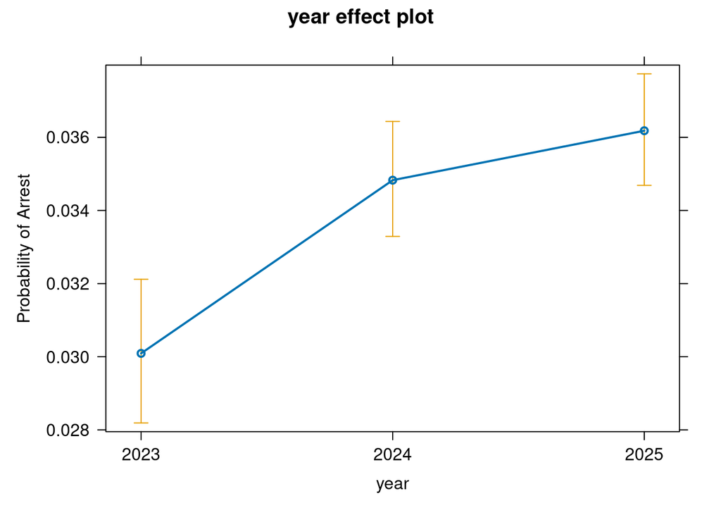

```r
plot(effect("year", mod_logit_best), rescale.axis=FALSE, ylab="Probability of Arrest")
```

Using **2023 as the reference year**, both 2024 and 2025 show statistically significant and higher odds of arrest.

- In 2024, the odds are estimated to be about **16% higher** than in 2023 (OR = 1.163);
- In 2025 they are about **21% higher** (OR = 1.210).

This pattern suggests a **gradual increase in the conditional odds of arrest across the three years**, after accounting for the remaining predictors.

#### 3.3.2.2) Month

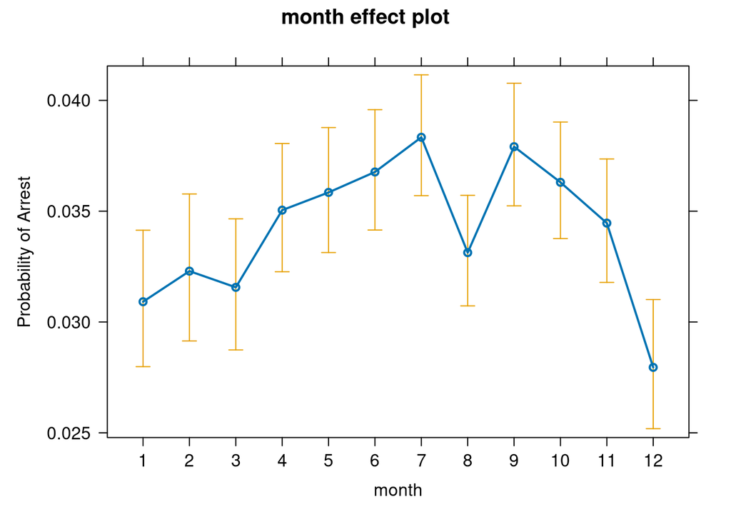

```r
plot(effect("month", mod_logit_best), rescale.axis=FALSE, ylab="Probability of Arrest")
```

The reference category for month is **January**. The OR are smaller than those for `hour` or `boro`.

The following months show **higher odds of arrest than January**:

- April (OR = 1.139),
- May (OR = 1.165),
- June (OR = 1.197),
- July (OR = 1.250),
- September (OR = 1.235),
- and October (OR = 1.181).

As expected from the EDA, **July has the largest estimated difference**, with approximately **25% higher odds**, followed closely by September.

On the other hand,

- February, March and August have odds ratios close to 1 and confidence intervals that clearly include 1, suggesting **little evidence of a difference from January**;
- November has an OR of 1.119 but does not reach conventional statistical significance ($p=0.082$);
- December has an OR below 1 (0.901), but its confidence interval also includes 1;

#### 3.3.2.3) Weekday

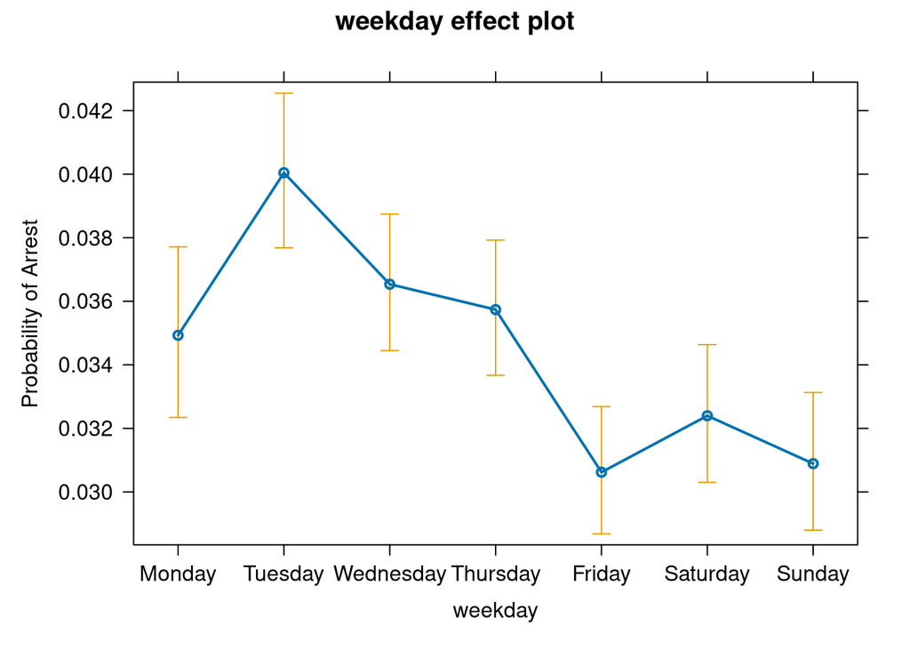

```r
plot(effect("weekday", mod_logit_best), rescale.axis=FALSE, ylab="Probability of Arrest")
```

Using **Monday as the reference**, most OR differences in weekday are small.

- Tuesday is surprisingly associated with significantly higher odds of arrest (OR = 1.153), corresponding to approximately **15% higher odds** than Monday, holding the remaining predictors fixed.
- Friday (OR = 0.873) and Sunday (OR = 0.881) are instead **associated with significantly lower odds, approximately 13% and 12% lower** than Monday, respectively.
- Wednesday and Thursday are very close to the reference value and **neither is statistically significant**. Saturday also shows lower odds, but the confidence interval includes 1.

#### 3.3.2.4) Hour

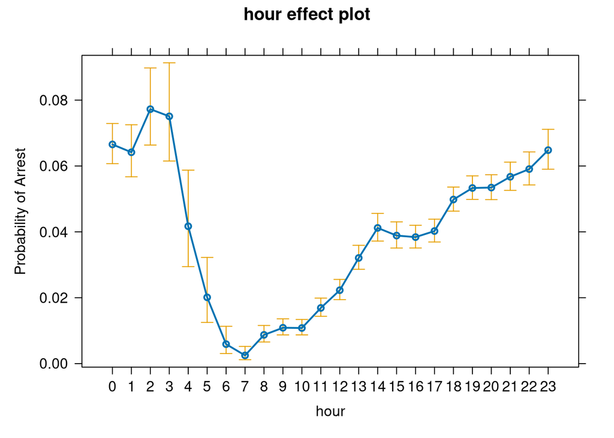

```r
plot(effect("hour", mod_logit_best), rescale.axis=FALSE, ylab="Probability of Arrest")
```

The reference hour is **00:00**, and this predictor shows one of the clearest patterns in the model.

- Hours **1, 2 and 3 do not differ significantly from midnight.**
- From approximately 04:00, the odds decrease sharply. At 04:00 the estimated OR is 0.610, already **indicating lower odds than at midnight**.
- There is another **great reduction between 05:00 and 12:00**.
  - At 05:00 OR = 0.288, and at 06:00 it decreases to 0.083.
  - The lowest value is observed at **07:00**, with OR = 0.035. In other words, conditional on all other included variables, the **odds of arrest at 07:00 are only about 3.5% of the corresponding odds at midnight**.
- The odds remain **very low during the rest of the morning**.
- From midday, the odds gradually increase again.
- By 21:00, the OR is 0.844. Then, at 22:00 (OR = 0.880, $p=0.053$) and 23:00 (OR = 0.972, $p=0.683$), the difference from midnight is no longer statistically significant.

This produces a **non-linear pattern coherent with EDA**: the conditional odds are highest around the reference hour, then they fall during the morning, and gradually build up towards midnight.

#### 3.3.2.5) Borough

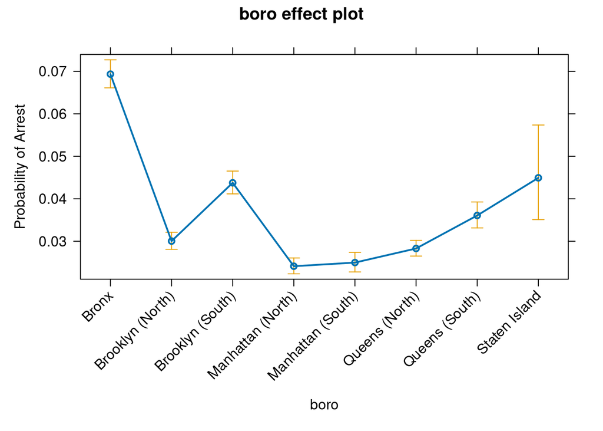

```r
plot(effect("boro", mod_logit_best), rescale.axis=FALSE, ylab="Probability of Arrest", rotx = 45)
```

The **Bronx is the reference category**, and every other borough has an odds ratio significantly below 1.

- The strongest differences are observed for Manhattan North (OR = 0.332) and Manhattan South (OR = 0.344). This means that (after fixing the other variables) the **estimated odds of arrest in these areas are roughly one third of those in the Bronx**.
- Queens North also has lower odds (OR = 0.391), followed by Brooklyn North (OR = 0.416), Queens South (OR = 0.502), Brooklyn South (OR = 0.614), and Staten Island (OR = 0.631).

#### 3.3.2.6) Sex

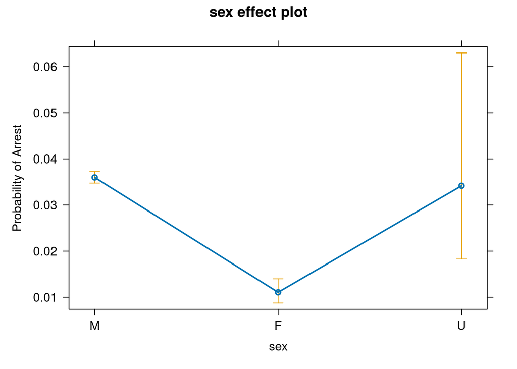

```r
plot(effect("sex", mod_logit_best), rescale.axis=FALSE, ylab="Probability of Arrest")
```

With **Male as the reference category**, `sexF` has an OR of 0.300 and the estimate is statistically significant. This indicates **substantially lower conditional odds** of arrest for female motorists (with respect to male drivers), after fixing the remaining predictors.

On the other hand, the `Unknown` category has an OR of 0.948 and a very wide confidence interval which includes 1, and a non-significant $p$-value. Thus, there is no evidence of a difference between the Unknown and Male categories in this model.

#### 3.3.2.7) Ethnicity

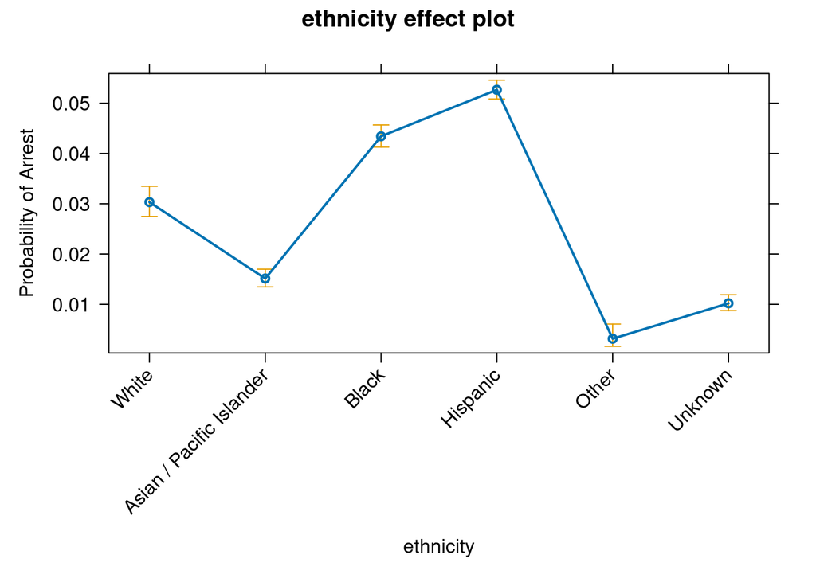

```r
plot(effect("ethnicity", mod_logit_best), rescale.axis=FALSE, ylab="Probability of Arrest", rotx = 45)
```

Using **White as the reference category**, the ethnicity coefficients show some of the largest differences in the model and are all statistically significant.

- The estimated odds for **Black observations are higher** than for the White reference group (OR = 1.451).
- **Hispanic** observations have an **even larger estimated OR** of 1.778, corresponding to approximately **78% higher conditional odds** relative to the White reference category.
- On the other hand, Asian / Pacific Islander has an OR of 0.491, indicating lower estimated odds. The `Other` category has a particularly small OR of 0.102 and `Unknown` has an OR of 0.330.

#### 3.3.2.8) Age bracket

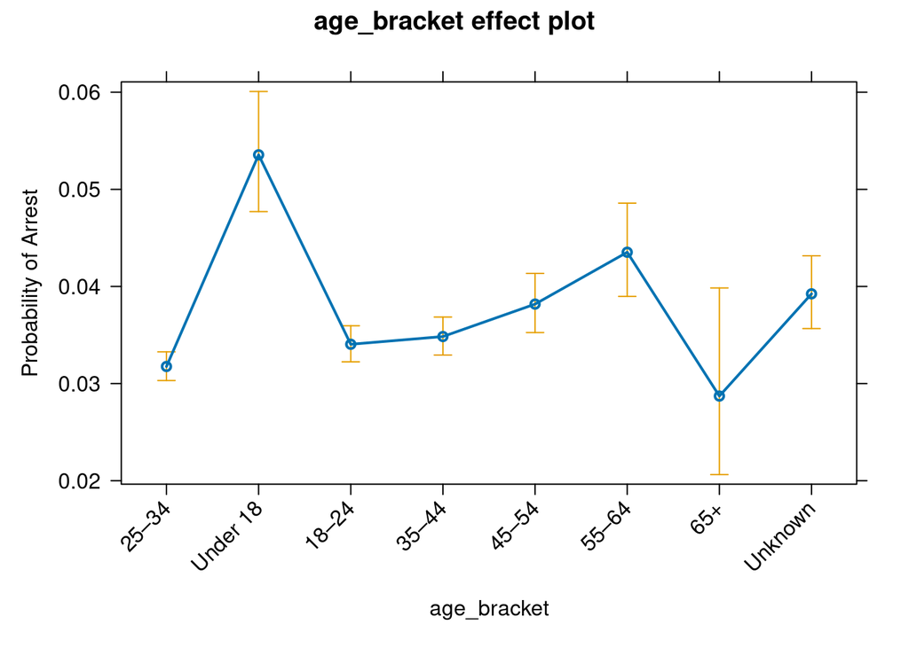

```r
plot(effect("age_bracket", mod_logit_best), rescale.axis=FALSE, ylab="Probability of Arrest", rotx = 45)
```

The reference age category is **25–34 years**.

- The strongest positive difference comes from the **Under 18** group, with an OR of 1.725. This corresponds to **higher conditional odds than the 25–34** reference group.
- The 18–24 category has an OR of 1.075. Although the **estimate is statistically significant**, the estimation is small and does not represent a huge difference from the reference category.
- For **older age groups, the estimated odds increase progressively** from 35–44 (OR = 1.101) to 45–54 (OR = 1.210) and 55–64 (OR = 1.387), and they are all statistically significant.
- The 65+ group is different: its OR is 0.901, but the confidence interval is wide and contains 1. Therefore, there is **no evidence of a significant difference between the 65+ and 25–34 groups**.
- The `Unknown` age category has an OR of 1.245 and is **statistically significant, indicating higher conditional odds relative to the reference group**.

## 3.4) Evaluation on Test Set

```r
# Select threshold on training data
prob_logit_train <- predict(mod_logit_best, newdata = train, type = "response")
roc_logit_train <- pROC::roc(train$arrested, prob_logit_train, quiet = TRUE)
thr_logit <- best_thresh(roc_logit_train)

prob_logit <- predict(mod_logit_best, newdata = test, type = "response")
roc_logit <- pROC::roc(test$arrested, prob_logit, quiet = TRUE)
auc_logit <- as.numeric(pROC::auc(roc_logit))
class_logit <- as.integer(prob_logit >= thr_logit)
met_logit <- class_metrics(test$arrested, class_logit)
```

### 3.4.1) Confusion Matrix

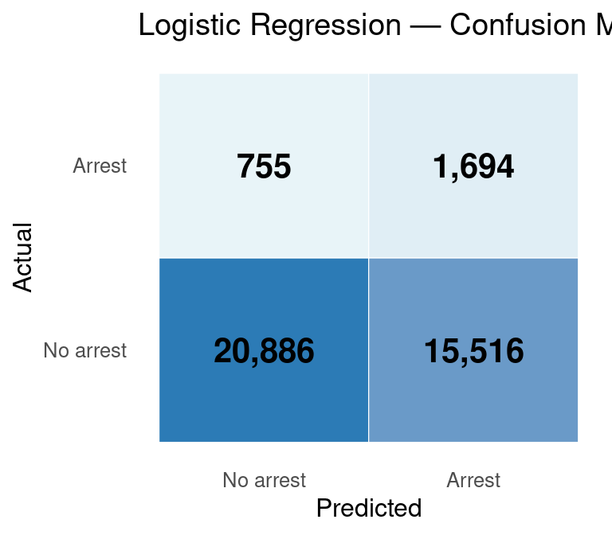

```r
plot_cm(test$arrested, class_logit, "Logistic Regression — Confusion Matrix (Youden threshold, train-selected)")
```

```r
cat(sprintf(
  "AUC: %.4f  |  Threshold (Youden, train-selected): %.4f\nSensitivity: %.3f  |  Specificity: %.3f  |  Balanced accuracy: %.3f\n",
  auc_logit, thr_logit, met_logit$sensitivity, met_logit$specificity, met_logit$balanced_acc
))
```

```
## AUC: 0.6868  |  Threshold (Youden, train-selected): 0.0491
## Sensitivity: 0.692  |  Specificity: 0.574  |  Balanced accuracy: 0.633
```

Let us start from the derived metrics:

| Metric | Value | Interpretation |
| --- | --- | --- |
| Accuracy | 0.581 | Overall proportion of correct classifications, of limited usefulness alone because of class imbalance |
| Sensitivity / Recall | 0.692 | About 69.2% of actual arrests are correctly detected |
| Specificity | 0.574 | About 57.4% of non-arrests are correctly identified |
| Precision | 0.098 | Only about 9.8% of observations predicted as arrests are actual arrests |
| F1 | 0.172 | Low harmonic mean of precision and recall, mainly constrained by low precision |
| Balanced Accuracy | 0.633 | Moderate performance after giving equal weight to both classes |

Overall, the confusion matrix confirms that the model identifies most arrests, but generates many false alarms. The 15,516 false positives substantially limit precision, despite the model detecting 1,694 of the 2,449 actual arrests.

### 3.4.3) Performance Analysis

This was partly covered in the previous section, so here we will be focusing on the metrics that we have yet to mention.

```r
compute_metrics(test$arrested, prob_logit, thr_logit, "Logistic Regression") %>%
  kbl(
    caption = "Logistic Regression — full evaluation metrics (test set; Youden threshold selected on training set)",
    col.names = c(
      "Model","AUC","PR-AUC","Log-Loss","Brier", "Threshold","Sensitivity",
      "Specificity","Precision","F1","MCC","Bal. Acc."
    )
  ) %>%
  kable_styling(bootstrap_options = c("striped","condensed"), full_width = TRUE)
```

Logistic Regression — full evaluation metrics (test set; Youden threshold selected on training set)

| Model | AUC | PR-AUC | Log-Loss | Brier | Threshold | Sensitivity | Specificity | Precision | F1 | MCC | Bal. Acc. |
| --- | --- | --- | --- | --- | --- | --- | --- | --- | --- | --- | --- |
| Logistic Regression | 0.6868 | 0.1207 | 0.2257 | 0.0576 | 0.0491 | 0.692 | 0.574 | 0.098 | 0.172 | 0.13 | 0.633 |

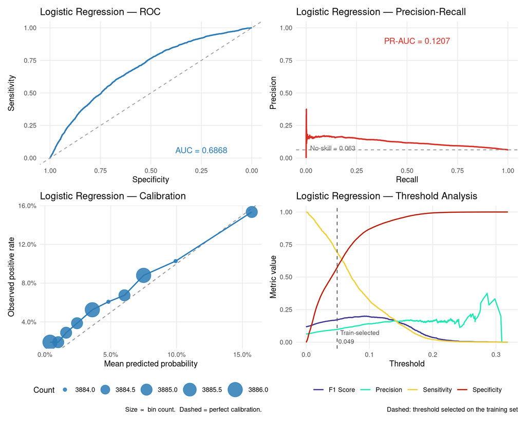

```r
eval_quad_plot(test$arrested, prob_logit, thr_logit, "Logistic Regression")
```

#### 3.4.3.1) Overall performance

| Metric | Value | Interpretation |
| --- | --- | --- |
| **AUC** | 0.6868 | Modest discrimination between arrests and non-arrests |
| **PR-AUC** | 0.1207 | Clearly above the no-skill baseline of $\approx 0.063$, but still low in absolute terms |
| **Log-Loss** | 0.2257 | Predicted probabilities contain useful information, with a modest improvement over a prevalence-only model |
| **Brier** | 0.0576 | Reasonably accurate probability estimates, but only slightly better than the prevalence baseline |
| Threshold | 0.0491 | Low cutoff, selected on the training set via Youden’s criterion and then applied unchanged to the test set |
| **MCC** | 0.130 | Weak positive association between predicted and observed classes |
| Balanced Accuracy | 0.633 | Moderate ability to distinguish both classes when they are weighted equally |

The main conclusion is that the Logistic Regression captures **meaningful but limited predictive signal**. It performs clearly better than chance, but its ability to identify arrests remains moderate and precision is low because arrests are a rare class.

#### 3.4.3.2) AUC

The test-set AUC is $\approx 0.687$.

This means that, when randomly comparing one arrested and one non-arrested observation, the model assigns the arrested case a higher predicted probability approximately **68.7% of the time**.

This is clearly above the random-classification value of $0.5$, indicating that the predictors contain useful information about arrest risk. However, the discrimination is only **modest** rather than strong: there remains substantial overlap between the predicted probabilities of arrests and non-arrests.

The ROC curve confirms this result, lying consistently above the diagonal no-skill line but remaining relatively far from the upper-left corner associated with strong classification performance.

#### 3.4.3.3) PR-AUC

This is particularly important given our imbalanced outcome.

Our positive class is rare, so ROC-AUC can sometimes give an overly optimistic impression of performance. **Precision-Recall AUC focuses directly on the positive class**, considering the trade-off between precision and recall.

Here, we obtain:

$$\text{PR-AUC} = 0.1207$$

The no-skill baseline corresponds approximately to the positive-class prevalence,

$$\text{PR-AUC}_{\text{baseline}} \approx
0.063$$

Thus, the model achieves a PR-AUC almost **1.9 times the prevalence baseline**.

*But how good is 0.1207?* It shows that the model contains useful information for ranking likely arrests, since it performs clearly better than random prediction. However, the absolute value remains low, indicating that retrieving arrests while maintaining high precision is difficult. This is also visible from the precision-recall curve, where precision falls as recall increases.

#### 3.4.3.4) Log-Loss

> Log-loss evaluates the **quality of the predicted probabilities**, rather than simply stating whether the final classification is correct.

This measure cares about **how confident the model is**. For example, predicting $p=0.51$ for an actual arrest is not treated the same as predicting $p=0.99$. In fact, a highly confident incorrect prediction receives a strong penalty.

In our case:

$$\text{Log-Loss} = 0.2257$$

For comparison, a prevalence-only model predicting approximately $p=0.063$ for every observation would have a log-loss of roughly $0.235$. The fitted logistic regression therefore improves on this baseline, although the reduction is relatively modest.

This suggests that the model’s probability estimates contain **genuine predictive information**, but the gain over simply knowing the overall arrest prevalence is limited.

#### 3.4.3.5) Brier Score

The Brier score is useful here because it evaluates whether the predicted probabilities are close to the observed outcomes, rather than merely whether the model ranks observations correctly.

> Formally, the Brier score measures the squared error of the predicted probabilities (the lower, the better).

The model obtains

$$\text{Brier} = 0.0576$$

A prevalence-only prediction of approximately $0.063$ would produce a Brier score of about $0.0590$. The logistic regression therefore provides a **small improvement in probability accuracy** over the baseline.

The calibration plot is broadly consistent with this result: the mean predicted probabilities and observed arrest rates remain reasonably close to the perfect-calibration diagonal overall, although deviations are visible in some probability ranges. This supports cautious interpretation of the Brier score and log-loss rather than a claim of perfect calibration.

#### 3.4.3.6) MCC

The **Matthews Correlation Coefficient (MCC)** is particularly useful for imbalanced classification because it incorporates all four components of the confusion matrix:

$$MCC = \frac{TP\cdot TN-FP\cdot
FN}{\sqrt{(TP+FP)(TP+FN)(TN+FP)(TN+FN)}} \in [-1, 1]$$
Where,

- $1$ = perfect prediction
- $0$ = no better than random association
- $-1$ = completely incorrect prediction

Our result is:

$$MCC = 0.130$$

This represents a **weak but positive association** between the predicted and observed classes. The classifier therefore performs better than random classification, but the relatively low MCC confirms that its threshold-based predictions remain limited.

This is consistent with the low precision of $0.098$: although the model identifies a meaningful proportion of arrests, many observations classified as arrests are actually non-arrests.

#### 3.4.3.7) Thresholds

Using Youden’s criterion, the selected classification threshold is

$$t^* = 0.0491$$

This threshold is selected once by maximising Youden’s $J$ on the training-set ROC curve, then frozen and applied unchanged to the test set, so no test-set information is used in choosing the cutoff.

This value is much lower than the conventional $0.5$ cutoff because the positive class is rare. A threshold of $0.5$ would classify very few observations as arrests and would therefore produce very poor sensitivity.

resulting in

$$\text{Balanced
Accuracy}=0.633$$

Thus, approximately **69.2% of actual arrests are detected**, while approximately **57.4% of non-arrests are correctly excluded**. Detecting more arrests at this low cutoff comes at the cost of a substantial number of false positives.

The threshold analysis shows the expected trade-off: lowering the threshold increases sensitivity but reduces specificity, while increasing it has the opposite effect.

Precision at this threshold remains low,

$$\text{Precision}=0.098$$

meaning that only about 9.8% of observations classified as arrests are actually arrests. This is an important consequence of the strong class imbalance.

#### 3.4.3.8) Final Remarks

Let us put the metrics together:

- **Discrimination**, $\text{AUC} \approx 0.687$: the model ranks arrests above non-arrests better than chance, but discrimination remains modest.
- **Rare-class performance**, $\text{PR-AUC} \approx 0.121$: performance is clearly above the no-skill baseline of $\approx 0.063$, although precision remains limited.
- **Probability predictions**, $\text{Brier} \approx 0.058, \,\, \text{LogLoss} \approx 0.226$: the estimated probabilities improve on prevalence-only predictions, but only moderately.
- **Classification**, $\text{MCC} \approx 0.130$: threshold-based predictions show a weak but genuine positive association with the observed outcome.
- **Class balance**, $\text{ACC}_{\text{Balanced}} \approx 0.633$: the model achieves moderate performance when sensitivity and specificity are given equal importance.

Now for the final conclusions:

- The Logistic Regression captures **real but limited predictive structure** in the arrest outcome.
- Its strongest result is its ability to rank observations better than chance, as reflected by the AUC and PR-AUC.
- Probability estimates are reasonably calibrated overall, but the improvement over a prevalence-only model is modest.
- The low positive-class prevalence strongly limits precision: even at the Youden threshold, many predicted arrests are false positives.
- The selected threshold represents a compromise between detecting arrests and avoiding false alarms, rather than a cutoff producing highly accurate individual classifications.
- Overall, the model is useful as an **interpretable baseline and risk-ranking model**, but its predictive performance is not sufficiently strong to treat individual classifications as highly reliable.

## 3.5) Diagnostics

### 3.5.1) Multicollinearity (VIF)

Variance Inflation Factors measure how much each predictor’s variance is inflated by collinearity with the others.

Because `mod_logit_best` contains several multi-level categorical predictors (generating multiple coefficients), multicollinearity is computed using the **Generalised Variance Inflation Factor (GVIF)** rather than the standard VIF.

The adjusted quantity $\text{GVIF}^{1/(2\,\text{df})}$ accounts for the number of degrees of freedom associated with each predictor and makes the values comparable across terms. In this sense, it can be interpreted on approximately the same scale as $\sqrt{VIF}$.

**How do we interpret this?**

- Values close to 1 indicate that the corresponding predictor has little linear dependence with the remaining predictors;
- Instead, larger values indicate potential multicollinearity.

```r
vif_tbl <- as.data.frame(car::vif(mod_logit_best))
vif_tbl$predictor <- rownames(vif_tbl)
rownames(vif_tbl) <- NULL

# Rename columns robustly (vif() returns 3-col df for factors)
if (ncol(vif_tbl) == 4) {
  names(vif_tbl)[1:3] <- c("GVIF", "Df", "GVIF_adj")
} else {
  names(vif_tbl)[1] <- "GVIF"
  vif_tbl$Df <- 1
  vif_tbl$GVIF_adj <- sqrt(vif_tbl$GVIF)
}

vif_tbl %>%
  arrange(desc(GVIF_adj)) %>%
  mutate(flag = ifelse(GVIF_adj > sqrt(5), "⚠ >sqrt5", "OK")) %>%
  kbl(
    digits = 3,
    caption = "Logistic regression — Generalised VIF (GVIF^(1/2df) comparable to sqrt(VIF))"
  ) %>%
  kable_styling(bootstrap_options = c("striped", "condensed"), full_width = FALSE)
```

Logistic regression — Generalised VIF (GVIF^(1/2df) comparable to sqrt(VIF))

| GVIF | Df | GVIF_adj | predictor | flag |
| --- | --- | --- | --- | --- |
| 1.259 | 5 | 1.023 | ethnicity | OK |
| 1.221 | 7 | 1.014 | boro | OK |
| 1.054 | 2 | 1.013 | year | OK |
| 1.050 | 2 | 1.012 | sex | OK |
| 1.050 | 6 | 1.004 | weekday | OK |
| 1.057 | 7 | 1.004 | age_bracket | OK |
| 1.059 | 11 | 1.003 | month | OK |
| 1.105 | 23 | 1.002 | hour | OK |

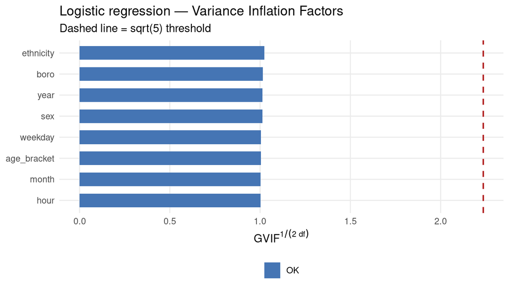

```r
ggplot(
  vif_tbl,
  aes(
    x = reorder(predictor, GVIF_adj),
    y = GVIF_adj,
    fill = GVIF_adj > sqrt(5)
  )
) +
  geom_col(width = 0.65) +
  geom_hline(
    yintercept = sqrt(5), linetype = "dashed",
    colour = "firebrick", linewidth = 0.7
  ) +
  scale_fill_manual(
    values = c("FALSE" = "#4575b4", "TRUE" = "#d73027"),
    labels = c("OK", ">5 threshold"), name = NULL
  ) +
  coord_flip() +
  labs(
    x = NULL,
    y = expression(GVIF^{1/(2~df)}),
    title = "Logistic regression — Variance Inflation Factors",
    subtitle = "Dashed line = sqrt(5) threshold"
  ) +
  theme_minimal(base_size = 11) +
  theme(legend.position = "bottom", panel.grid.minor = element_blank())
```

In this model, all adjusted GVIF values are extremely close to 1, ranging from **1.002** for `hour` to **1.023** for `ethnicity`**. Even the largest values, for `ethnicity` ($1.023$) and `boro` ($1.014$), are far below levels that would normally raise concern.

Therefore, there is **no evidence of problematic multicollinearity among the predictors**. This is particularly relevant for predictors such as `hour`, `month`, and `boro`, which contain many factor levels but still show adjusted GVIF values essentially equal to 1.

### 3.5.2) Influential Observations

Influence diagnostics assess whether individual observations have an unusually large effect on the fitted logistic regression model.

Here we consider **Cook’s distance** which measures how much the fitted model would change if a given observation were removed.

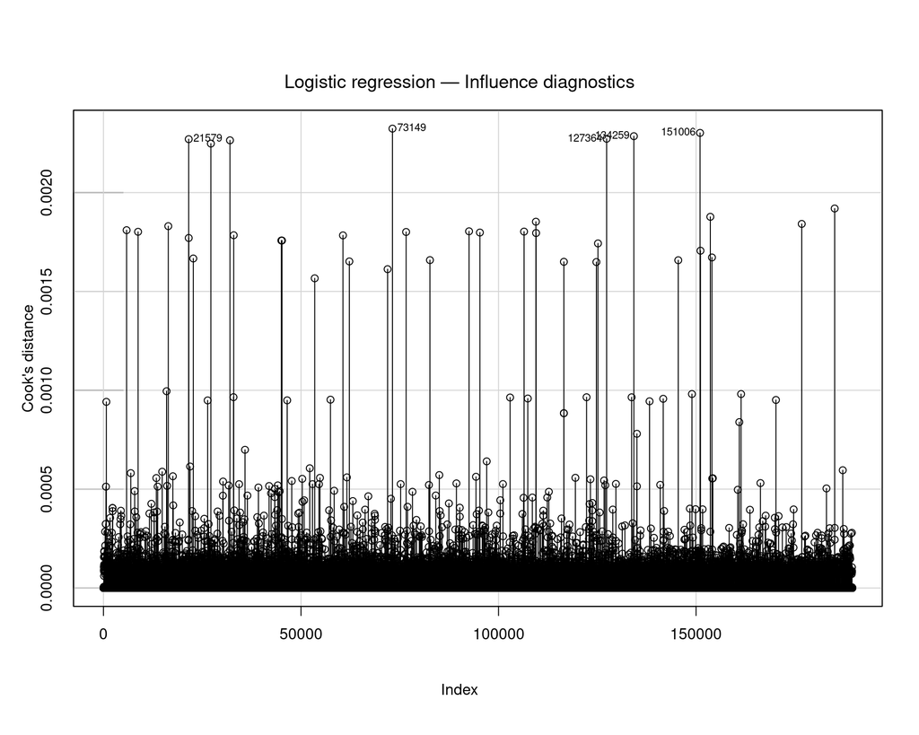

```r
car::influenceIndexPlot(
  mod_logit_best,
  vars = c("Cook"),
  id = list(n = 5, cex = 0.7),
  main = "Logistic regression — Influence diagnostics"
)
```

In the plot, the vast majority of observations have Cook’s distances very close to zero. This shows that individual obs. tend to have little influence on the fitted model. A small batch of observations show larger values, but none of them appears to dominate the model.

Overall, the Cook’s distance diagnostic suggests that the logistic regression is **not being driven by a small number of highly influential observations**.